# CASE STUDY: STACK OVERFLOW QUESTIONS

### 8.3 The bind_rows verb

So far we combined tables based on values that match between them. In some situations, instead of joining one variable next to each other, we may want to stack one on top of the other by binding rows.

```r
posts <- questions %>%
  bind_rows(answers)
posts
```

```
## # A tibble: 675,378 x 4
##          id creation_date score question_id
##       <int> <date>        <int>       <int>
##  1 22557677 2014-03-21        1          NA
##  2 22557707 2014-03-21        2          NA
##  3 22558084 2014-03-21        2          NA
##  4 22558395 2014-03-21        2          NA
##  5 22558613 2014-03-21        0          NA
##  6 22558677 2014-03-21        2          NA
##  7 22558887 2014-03-21        8          NA
##  8 22559180 2014-03-21        1          NA
##  9 22559312 2014-03-21        0          NA
## 10 22559322 2014-03-21        2          NA
## # ... with 675,368 more rows
```

The original **questions** table has 294,000 questions and the **answers** table has 380,000 answers. After performing the `bind_rows` verb we now have 675,000 observations. The `question_id` column of first observations has `N`A because those are questions originally, and only the answers table has that column.

It is useful to keep track of which observations are questions and which are answers:

```r
questions_type <- questions %>%
  mutate(type = "question")
answers_type <- answers %>%
  mutate(type = "answer")
posts <- questions_type %>%
  bind_rows(answers_type)
```

We can do some aggregation with the new table, for example, to find the average score of questions and answers.

```r
posts %>%
  group_by(type) %>%
  summarise(average_score = mean(score))
```

```
## # A tibble: 2 x 2
##   type     average_score
##   <chr>            <dbl>
## 1 answer            2.88
## 2 question          1.90
```

We see the average score for the answers is higher rated than the average one for the questions. But the aggregations can get a lot more complicated than that. For instance, we can look at question and answer activity over time. To calculate the `creation_date` variable for year, rather than just date, we use the `year()` function from the **lubridate** package, which takes a date and turns it into a relevant year.

```r
library(lubridate)
questions_answers_year <- posts %>%
  mutate(year = year(creation_date)) %>%
  count(year, type) # find number of posts of each type by year.
```

This is especially useful for a visualization, since it is ready for using in **ggplot2**. Plotting the `date` variable:

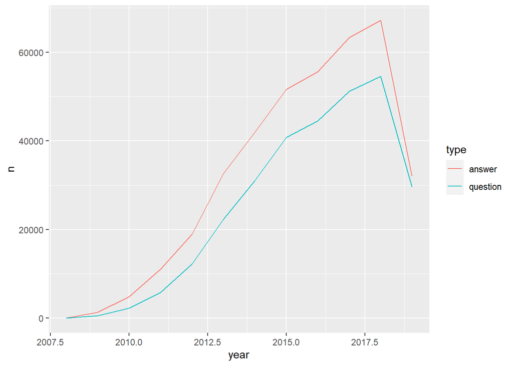

```r
ggplot(questions_answers_year,
       aes(year, n,
           color = type)) +
  geom_line()
```

To learn more about the **questions** and **answers** table, we will want to use the **question_tags** table to understand the tags associated with each question that was asked, and each answer that was provided. Joining **questions** and **answers** with **tags**:

```r
questions_with_tags <- questions %>%
  inner_join(question_tags, by = c("id" = "question_id")) %>%
  inner_join(tags, by = c("tag_id" = "id"))
answers_with_tags <- answers %>%
  inner_join(question_tags, by = "question_id") %>%
  inner_join(tags, by = c("tag_id" = "id"))
```

Now we will be able to combine each of these individual tables into a single cohesive table to have a better understanding of the information we have about the questions, answers, and associated tags. Next we combine these tables into a single table again. Once the information is consolidated into a single table, we can add more information.

Binding and counting posts with tags:

```r
post_with_tags <- bind_rows(questions_with_tags %>%
                              mutate(type = "question"),
                            answers_with_tags %>%
                              mutate(type = "answer"))
```

Add a `year` column to the **posts_with_tags** table, then aggregate to count posts by `type`, `year`, and `tag_name`:

```r
by_type_year_tag <- post_with_tags %>%
  mutate(year = year(creation_date)) %>%
  count(type, year, tag_name)
```

Visualize questions and answers for the dplyr and ggplot2 tag names:

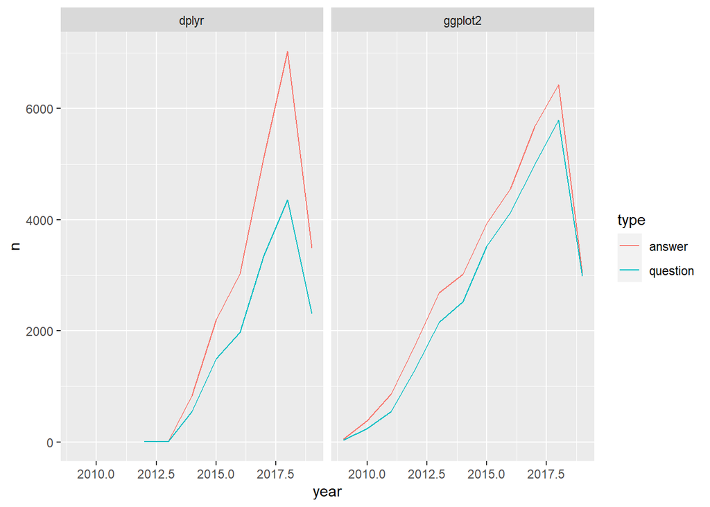

```r
by_type_year_tag_filtered <- by_type_year_tag %>%
  filter(tag_name == "dplyr" | tag_name == "ggplot2")
# Create a line plot faceted by the tag name:
ggplot(by_type_year_tag_filtered, aes(year, n, color = type)) +
  geom_line() +
  facet_wrap(~ tag_name)
```

Notice answers on **dplyr** questions are growing faster than **dplyr** questions themselves; meaning the average **dplyr** question has more answers than the average **ggplot2** question.